# Q*, Q* mode consistency

This notebook is a trial to confirm theoretical results for Q* consensus and Q* mode consensus.

- Q* mode consensus: When constructing the set $Q_{maj}$, instead of counting number of occurences, we do mode estimation and store the topology of the mode.

## Q* consistency

Consistency of R* consensus is investigated by Degnan et al. The exact same argument can be used.

The following theorem is the basic property.

**Theorem** Let $T$ be the “true” **binary** tree, and let $P$ be a distribution of trees with the same leaf set. Suppose that $P$ has the following property: (*) For any quartets $ab\mid cd$, $P(ab\mid cd \in T) > \max\{ P(ac\mid bd \in T), P(ad\mid bc \in T)\}$ Then, Q* consensus tree constructed from an independent sample $X$ is consistent.

**********Proof**********

The proof is essentially the same with the proof of Theorem 3 in Degnan et al. (2009).

Take $\varepsilon>0$ arbitrarily and let $X_1, \ldots, X_n$ denote a sample of size $n$. Because the number of quartets is finite, we can take $n$ sufficiently large such that with probability greater than $1-\varepsilon$, for all quartets $ab\mid cd\in T$, $P_n(ab\mid cd) > \max\{ P_n(ac\mid bd \in T), P_n(ad\mid bc \in T)\}$. Here, $P_n$ denotes the empirical measure. Then for the sample with this probability, Q* recovers the true topology.

Note that the above argument is only applicable to the binary case.

Now the question of whether Q* is consistent under different configurations just comes down to asking if the distribution $P$ where sample is drawn satisfies the condition (*).

💡 **It would be interesting to see in simulation if the condition (*) is satisfied for bootstrap trees.**

## Q* mode consistency

Suppose that gene trees $T_1, \ldots, T_n$ are obtained by multi-species coalescent model (branch lengths are in coalescent units).

💡 Q(A). Does the subtree of gene trees also follow multispecies coalescent? By using a suitable time scaling (coalescent units?), can each branch’s population size be assumed as the same?

💡 We can casually check this assumption using simulation with dendropy or inspecting the code.

If A holds, then for a fixed subset of taxa, the subtree of gene trees restricted to this subset also follows the multispecies coalescent with the same pop size for each edge.

Let $q$ be an arbitrary quartet of taxa and let $T_1^{(q)}, \ldots, T_n^{(q)}$ be the subtrees restricted to $q$. Since pop size is fixed and they are independent sample from the same coalescent process, the mode estimator consistently estimates the correct phylogeny w.r.t. its topology and one (and only) internal edge length. Thus, in particular, for any $\delta, \varepsilon>0$, there exists $N\in\mathbb{N}$ such that if $n\geq N^{(q)}$, with probability greater than $1-\frac{\varepsilon}{\binom{m}{4}}$, the distance (in BHV) between the mode estimator and true subtree can be made less than $\delta$. Because we only have a finite number of quartets, by suitably choosing large $N$, if $n\geq N$, with probability greater than $1-\varepsilon$, the maximum distance between each mode estimator and true subtree is less than $\delta$. This shows the weak consistency of Q* mode consensus.

#### Some codes (you can skip)

```python
from consensus import *
import matplotlib.pyplot as plt
import consensus
import dendropy
import random
import numpy as np
from tqdm.notebook import trange, tqdm
import pickle
import pandas as pd
```

```python
sample_sizes = [50, 100, 300, 500]
num_samples = 50
num_species_tree = 20
```

```python
with open("simulation_data/MSC_1015/true_trees.pkl", "rb") as f:
    true_trees = pickle.load(f)
```

```python
ResultDF = pd.DataFrame(index = [i for i in range(20)])
for sample_size in tqdm(sample_sizes):
    with open(f"simulation_data/MSC_1015/qstarmode_{sample_size}_dict.pkl", "rb") as f:
        qstarmode_dict = pickle.load(f)
    with open(f"simulation_data/MSC_1015/qstar_{sample_size}_dict.pkl", "rb") as f:
        qstar_dict = pickle.load(f)

    sds_dict_qstarmode = dict()
    sds_dict_qstar = dict()
    for i in trange(20):
        true = Tree_with_support.get(data=true_trees[i].as_string("newick", suppress_rooting=True), schema="newick", taxon_namespace = true_trees[i].taxon_namespace)
        sds_qstar = []; sds_qstarmode = [];
        for j in range(50):
            qstarmode = Tree_with_support(qstarmode_dict[(i, sample_size, j)], taxon_namespace = true.taxon_namespace)
            #sds.append(distance_p4(true, qstarmode))
            sds_qstarmode.append(dendropy.calculate.treecompare.symmetric_difference(true, qstarmode))
            qstar = Tree_with_support(qstar_dict[(i, sample_size, j)], taxon_namespace = true.taxon_namespace)
            #sds.append(distance_p4(true, qstarmode))
            sds_qstar.append(dendropy.calculate.treecompare.symmetric_difference(true, qstar))
        sds_dict_qstarmode[i] = sds_qstarmode
        sds_dict_qstar[i] = sds_qstar
    sds_qstarmode_mean = dict(); sds_qstarmode_std = dict()
    for key, val in sds_dict_qstarmode.items():
        sds_qstarmode_mean[key] = np.mean(val)
        sds_qstarmode_std[key] = np.std(val)
    sds_qstar_mean = dict(); sds_qstar_std = dict()
    for key, val in sds_dict_qstar.items():
        sds_qstar_mean[key] = np.mean(val)
        sds_qstar_std[key] = np.std(val)
    ResultDF[f"qstar_mean_{sample_size}"] = sds_qstar_mean
    ResultDF[f"qstar_std_{sample_size}"] = sds_qstar_std
    ResultDF[f"qstarmode_mean_{sample_size}"] = sds_qstarmode_mean
    ResultDF[f"qstarmode_std_{sample_size}"] = sds_qstarmode_std
```

```python
ResultDF
```

|  | qstar_mean_50 | qstar_std_50 | qstarmode_mean_50 | qstarmode_std_50 | qstar_mean_100 | qstar_std_100 | qstarmode_mean_100 | qstarmode_std_100 | qstar_mean_300 | qstar_std_300 | qstarmode_mean_300 | qstarmode_std_300 | qstar_mean_500 | qstar_std_500 | qstarmode_mean_500 | qstarmode_std_500 |
| --- | --- | --- | --- | --- | --- | --- | --- | --- | --- | --- | --- | --- | --- | --- | --- | --- |
| 0 | 0.58 | 0.666033 | 1.48 | 0.670522 | 0.32 | 0.545527 | 1.14 | 0.663626 | 0.00 | 0.000000 | 0.66 | 0.620000 | 0.00 | 0.000000 | 0.62 | 0.561783 |
| 1 | 1.12 | 0.840000 | 1.38 | 0.935735 | 1.32 | 0.785875 | 1.36 | 0.685857 | 1.14 | 0.916733 | 1.30 | 0.781025 | 1.02 | 0.882950 | 0.88 | 0.765245 |
| 2 | 0.00 | 0.000000 | 0.28 | 0.567098 | 0.00 | 0.000000 | 0.20 | 0.447214 | 0.00 | 0.000000 | 0.00 | 0.000000 | 0.00 | 0.000000 | 0.00 | 0.000000 |
| 3 | 0.66 | 0.551725 | 1.32 | 0.733212 | 0.24 | 0.427083 | 0.80 | 0.692820 | 0.06 | 0.237487 | 0.52 | 0.574108 | 0.04 | 0.195959 | 0.58 | 0.568859 |
| 4 | 0.88 | 0.930376 | 1.70 | 1.118034 | 0.64 | 0.768375 | 1.60 | 1.039230 | 0.14 | 0.447661 | 0.68 | 0.733212 | 0.10 | 0.412311 | 0.72 | 0.749400 |
| 5 | 2.54 | 0.780000 | 2.96 | 0.598665 | 2.28 | 0.960000 | 2.94 | 0.506360 | 1.12 | 0.840000 | 2.66 | 0.681469 | 0.76 | 0.763151 | 2.58 | 0.750733 |
| 6 | 0.20 | 0.447214 | 0.82 | 0.683813 | 0.00 | 0.000000 | 0.46 | 0.573062 | 0.00 | 0.000000 | 0.20 | 0.489898 | 0.00 | 0.000000 | 0.06 | 0.237487 |
| 7 | 0.42 | 0.666033 | 1.64 | 0.995188 | 0.22 | 0.460000 | 1.16 | 0.783837 | 0.00 | 0.000000 | 0.46 | 0.606960 | 0.00 | 0.000000 | 0.28 | 0.491528 |
| 8 | 2.18 | 0.841190 | 2.48 | 0.727736 | 2.10 | 0.830662 | 2.18 | 0.554617 | 1.86 | 0.894651 | 2.06 | 0.369324 | 1.62 | 1.017644 | 1.96 | 0.564269 |
| 9 | 1.48 | 0.964158 | 2.24 | 1.123566 | 1.46 | 0.921086 | 2.28 | 0.980612 | 0.94 | 0.903549 | 1.90 | 0.964365 | 1.18 | 0.817068 | 1.92 | 0.890842 |
| 10 | 0.90 | 0.921954 | 2.00 | 1.200000 | 0.40 | 0.748331 | 1.58 | 1.097087 | 0.02 | 0.140000 | 1.06 | 1.027813 | 0.00 | 0.000000 | 0.90 | 0.943398 |
| 11 | 0.04 | 0.280000 | 0.56 | 0.668132 | 0.00 | 0.000000 | 0.28 | 0.633719 | 0.00 | 0.000000 | 0.04 | 0.195959 | 0.00 | 0.000000 | 0.02 | 0.140000 |
| 12 | 0.90 | 0.900000 | 2.30 | 0.806226 | 0.26 | 0.558928 | 2.12 | 0.886341 | 0.00 | 0.000000 | 1.28 | 0.775629 | 0.00 | 0.000000 | 0.70 | 0.700000 |
| 13 | 2.78 | 0.701142 | 3.02 | 0.423792 | 2.18 | 0.887468 | 2.98 | 0.547357 | 1.50 | 0.670820 | 2.82 | 0.477074 | 1.02 | 0.647765 | 2.78 | 0.609590 |
| 14 | 2.42 | 0.918477 | 2.34 | 0.737835 | 2.06 | 0.967678 | 2.16 | 0.808950 | 1.90 | 1.081665 | 2.16 | 0.611882 | 1.62 | 1.037111 | 1.96 | 0.823650 |
| 15 | 1.38 | 0.891964 | 2.70 | 0.830662 | 1.04 | 0.870862 | 2.26 | 0.769675 | 0.36 | 0.520000 | 1.78 | 0.900888 | 0.28 | 0.530660 | 1.54 | 0.780000 |
| 16 | 0.20 | 0.600000 | 0.84 | 0.924338 | 0.02 | 0.140000 | 0.46 | 0.805233 | 0.00 | 0.000000 | 0.24 | 0.649923 | 0.00 | 0.000000 | 0.14 | 0.490306 |
| 17 | 0.20 | 0.400000 | 1.16 | 0.757892 | 0.00 | 0.000000 | 0.44 | 0.571314 | 0.00 | 0.000000 | 0.44 | 0.535164 | 0.00 | 0.000000 | 0.30 | 0.458258 |
| 18 | 0.50 | 0.806226 | 1.42 | 0.940000 | 0.44 | 0.778717 | 0.82 | 0.887468 | 0.12 | 0.430813 | 0.62 | 0.797245 | 0.00 | 0.000000 | 0.24 | 0.549909 |
| 19 | 1.74 | 0.955196 | 2.10 | 0.781025 | 1.60 | 1.000000 | 1.86 | 0.748599 | 1.00 | 0.800000 | 1.92 | 0.658483 | 0.90 | 0.754983 | 1.74 | 0.743236 |

## Result

The following plots are plot of logatirhm of symmetric differnece (y-axis) vs sample size (x-axis) for each sample

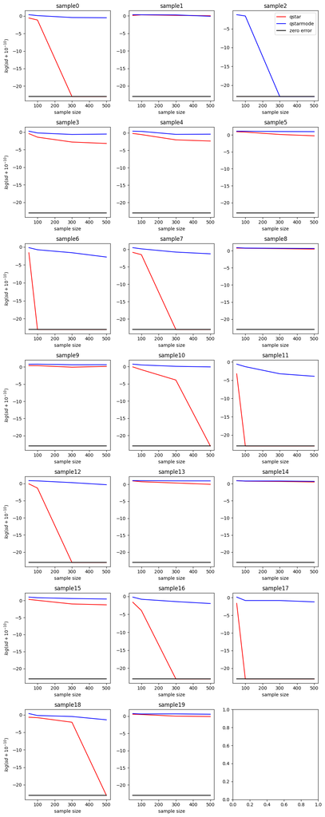

```python
fig, ax = plt.subplots(nrows=7, ncols=3, figsize = (10,25))
for i in range(20):
    data = ResultDF.loc[i][["qstar_mean_50", "qstar_mean_100", "qstar_mean_300", "qstar_mean_500"]].to_numpy()
    data2 = ResultDF.loc[i][["qstarmode_mean_50", "qstarmode_mean_100", "qstarmode_mean_300", "qstarmode_mean_500"]].to_numpy()
    ax[i//3, i%3].plot([50,100,300,500], np.log(data + 1e-10), color="red", label = "qstar")
    ax[i//3, i%3].plot([50,100,300,500], np.log(data2 + 1e-10), color="blue", label = "qstarmode")
    ax[i//3, i%3].plot([50,100,300,500], [np.log(1e-10) for _ in range(4)], color="black", label = "zero error")
    ax[i//3, i%3].set_title(f"sample{i}")
    ax[i//3, i%3].set_xlabel("sample size")
    if i%3==0:
        ax[i//3, i%3].set_ylabel("$log(sd + 10^{-10})$")
ax[0,2].legend(loc="upper right")
plt.tight_layout()
```

## Results

- The error looks quite unstable... (need more samples?).
- original qstar looks to perform better in almost all samples than qstar_mode.
  - It probably is partly due to the estimaition procedure I used for the mode estimation: the hyperparameter is not tuned correctly as of yet, and more sophisticated methods (probably KDE mode) should perform better (which is already confirmed in another experiment I did before.)